# Computer Vision

# 1 Introduction

This page aims at providing links to useful materials for my undergrads+postgrads for learning about Computer Vision and related fields.

## 1.1 Useful Prerequises

- Linear Algebra e.g. [Computational Linear Algebra](https://github.com/michiganrobotics/rob101)
- Programming e.g. [Python](https://www.python.org/about/gettingstarted/)

## 1.2 Online References

*books*

- [Computer Vision: Algorithms and Applications](https://szeliski.org/Book/) by Richard Szeliski
- [Pattern Recognition and Machine Learning](https://www.microsoft.com/en-us/research/uploads/prod/2006/01/Bishop-Pattern-Recognition-and-Machine-Learning-2006.pdf) by Christopher M. Bishop
- [Data Mining and Analysis; Fundamental Concepts and Algorithms](https://doc.lagout.org/Others/Data%20Mining/Data%20Mining%20and%20Analysis_%20Fundamental%20Concepts%20and%20Algorithms%20%5BZaki%20%26%20Meira%202014-05-12%5D.pdf) by Mohammed J. Zaki and Wagner Meira Jr.
- https://d2l.ai/
- https://www.deeplearningbook.org/
- [The Modern Mathematics of Deep Learning](https://arxiv.org/abs/2105.04026) (advanced)
- [Graph Representation Learning](https://www.cs.mcgill.ca/~wlh/grl_book/files/GRL_Book.pdf) W. L. Hamilton
- [Reinforcement Learning: An Introduction](http://www.incompleteideas.net/book/the-book.html) by Richard S. Sutton and Andrew G. Barto
- [High-Dimensional Data Analysis with Low-Dimensional Models: Principles, Computation, and Applications](https://book-wright-ma.github.io/) by John Wright and Yi Ma

*youtube videos and PDF slides*

- http://introtodeeplearning.com MIT Introduction to Deep Learning
- [Deep Learning for Computer Vision](https://www.youtube.com/playlist?list=PL5-TkQAfAZFbzxjBHtzdVCWE0Zbhomg7r) by Justin Johnson
- [ICLR 2021 Keynote - “Geometric Deep Learning: The Erlangen Programme of ML” - M Bronstein](https://youtu.be/w6Pw4MOzMuo)

*Miscellaneous*

- [Datasets](https://paperswithcode.com/datasets?q=&v=lst&o=match)
- [Connected papers](https://www.connectedpapers.com)

> 800 free computer science classes you can take online right now: https://t.co/RURjy6O01h [pic.twitter.com/Bm97oHBBZ2](https://t.co/Bm97oHBBZ2)

> — MIT CSAIL (@MIT_CSAIL) [January 23, 2022](https://twitter.com/MIT_CSAIL/status/1485303818384396289?ref_src=twsrc%5Etfw)

## 1.3 Conferences & Journals

- [Google Scholar Ranking: Computer Vision and Pattern Recognition](https://scholar.google.com/citations?view_op=top_venues&hl=en&vq=eng_computervisionpatternrecognition)
- [Google Scholar Ranking: Artificial Intelligence](https://scholar.google.com/citations?view_op=top_venues&hl=en&vq=eng_artificialintelligence)

# 2 Lecturenotes

## 2.1 Slides CS410

- [Histogram Equalisation](https://roznn.github.io/SLIDES/Slides_HistogramEqualisation.html)
- [Meanshift](https://roznn.github.io/SLIDES/Slides_Meanshift.html)
- [Computer Vision with Machine Learning](https://roznn.github.io/SLIDES/Slides_CVML.html): Overview, dataset preparation $\lbrace x_i,y_i\rbrace_{i=1,\cdots,N}$, and AI Ethics
- [Loss Functions](https://roznn.github.io/SLIDES/Slides_LossFunctions.html): Loss functions $\mathcal{L}$
- [Backpropagation](https://roznn.github.io/SLIDES/Slides_Backpropagation.html): computation of parameters $\hat{\theta}$
- [Machine Design](https://roznn.github.io/SLIDES/Slides_MachineDesign.html): Machines $f_{\theta}$
- [Formulas](https://roznn.github.io/SLIDES/Slides_Formula.html)

## 2.2 Timeline

[interactive chart not shown]

| Label | Information |
| --- | --- |
| [ResNet](https://arxiv.org/abs/1512.03385) | Residual Networks : type of neural network architecture https://pytorch.org/hub/pytorch_vision_resnet/ |
| [VGG](https://arxiv.org/abs/1409.1556) | VGG : type of neural network architecture |
| [AlexNet](https://proceedings.neurips.cc/paper/2012/file/c399862d3b9d6b76c8436e924a68c45b-Paper.pdf) | AlexNet : type of neural network architecture |
| [PASCAL](http://host.robots.ox.ac.uk/pascal/VOC/) | PASCAL (dataset) |
| [Imagenet](https://www.image-net.org/) | ImageNet (dataset) |
| [Backpropagation](https://doi.org/10.1038/323533a0) | Backpropagation (Algorithm for optimisation of Neural Networks) - Slides https://roznn.github.io/SLIDES/Slides_Backpropagation.html |
| [LeNet](https://doi.org/10.1162/neco.1989.1.4.541) | LeNet, earliest Convolutional Neural Networks |
| [VAE](https://arxiv.org/abs/1312.6114) | Variational Auto Encoder : type of neural network architecture |
| Deep Learning Era | Deep learning for AI: How can neural networks learn the rich internal representations required for difficult tasks such as recognizing objects or understanding language? https://doi.org/10.1145/344825… |
| [GAN](https://proceedings.neurips.cc/paper/2014/file/5ca3e9b122f61f8f06494c97b1afccf3-Paper.pdf) | Generative Adversarial Networks : type of neural network architecture used for synthesis |
| [Transformer](https://proceedings.neurips.cc/paper/2017/file/3f5ee243547dee91fbd053c1c4a845aa-Paper.pdf) | Transformers : type of neural network architecture |
| [Mean Shift](https://doi.org/10.1109/34.1000236) | Mean shift: a robust approach toward feature space analysis. Paper https://doi.org/10.1109/34.1000236 - Slides https://roznn.github.io/SLIDES/Slides_Meanshift.html |
| RANSAC | Random sample consensus (RANSAC): Robust estimation technique able to handle outliers published by Fischler and Bolles |
| Hough Transform | Hough Transform (https://inspirehep.net/literature/919922) is a robust technique to estimate parameters of shapes (e.g. lines). The Hough Transform is related to the Radon Transform ( http://doi.org/1… |
| Radon Transform | Radon Transform is used in tomography (e.g. Xrays). |
| Fourier Transform | Fourier transform allows to express space-time functions in a frequency domain. The convolution operation becomes a multiplication in the Fourier (frequency) domain. |
| [Viola & Jones](http://vision.stanford.edu/teaching/cs231b_spring1213/papers/CVPR01_ViolaJones.pdf) | Face detector using Haar wavelets and Cascade classifiers by Viola and Jones https://docs.opencv.org/3.4/db/d28/tutorial_cascade_classifier.html |
| OpenCV | OpenCV (Open Source Computer Vision Library) is a library for computer vision. |
| [Lena](https://pursuit.unimelb.edu.au/articles/it-s-time-to-retire-lena-from-computer-science) | https://pursuit.unimelb.edu.au/articles/it-s-time-to-retire-lena-from-computer-science |
| Markov Random Field models | Markov Random Field models, by Geman & Geman https://doi.org/10.1109/TPAMI.1984.4767596 |
| [NeRF](https://dx.doi.org/10.1145/3503250) | NeRF: Neural Radiance Fields |
| PCA image learning | Probabilistic visual learning for object representation https://doi.org/10.1109/34.598227 |
| Active appearance models | https://doi.org/10.1109/34.927467 |

# 3 Architectures

Type of convolution https://xzz201920.medium.com/conv1d-conv2d-and-conv3d-8a59182c4d6

## 3.1 ConvNet

Source: https://keras.io/examples/vision/mnist_convnet/

```
model = keras.Sequential(
    [
        keras.Input(shape=input_shape),
        layers.Conv2D(32, kernel_size=(3, 3), activation="relu"),
        layers.MaxPooling2D(pool_size=(2, 2)),
        layers.Conv2D(64, kernel_size=(3, 3), activation="relu"),
        layers.MaxPooling2D(pool_size=(2, 2)),
        layers.Flatten(),
        layers.Dropout(0.5),
        layers.Dense(num_classes, activation="softmax"),
    ]
)

model.summary()
```

```
Model: "sequential"
_________________________________________________________________
Layer (type)                 Output Shape              Param #
=================================================================
conv2d (Conv2D)              (None, 26, 26, 32)        320
_________________________________________________________________
max_pooling2d (MaxPooling2D) (None, 13, 13, 32)        0
_________________________________________________________________
conv2d_1 (Conv2D)            (None, 11, 11, 64)        18496
_________________________________________________________________
max_pooling2d_1 (MaxPooling2 (None, 5, 5, 64)          0
_________________________________________________________________
flatten (Flatten)            (None, 1600)              0
_________________________________________________________________
dropout (Dropout)            (None, 1600)              0
_________________________________________________________________
dense (Dense)                (None, 10)                16010
=================================================================
Total params: 34,826
Trainable params: 34,826
Non-trainable params: 0
_________________________________________________________________
```

This model is designed with a first convolution layer taking an image $(28\times 28 \times 1)$ (MNIST are grey level images of width 28 and height 28) and computing 32 maps using 32 filters of size $(3\times 3\times 1)$ creating a output tensor of size $26 \times 26 \times 32$ (as no padding is applied). The 32 filters have $3\times3\times 32=288$ parameters and in addition 32 biases need to be estimated leading to a total of $288+32=320$ parameters to be estimated in this first convolution.

[figure not shown]

Convolution of the input image with 32 filters of size 3x3 on the first layer

The maxpooling operation down-samples by 2 in spatial dimensions creating a tensor of size $(\frac{26}{2} \times \frac{26}{2} \times 32)=(13 \times 13 \times 32)$.

The second convolution layer operates on the input tensor $(13 \times 13 \times 32)$ using 64 filters of size $(3\times 3 \times 32)$ creating an output tensor of size $(11 \times 11 \times 64)$ (no padding used). The 64 filters have $3\times3\times 32\times 64=18432$ parameters and in addition 64 biases need to be estimated leading to a total of $18432+64=18496$ parameters to be estimated in this second convolution layer.

[figure not shown]

Second convolutional layer with 64 filters

The maxpooling operation down-samples by 2 in spatial dimension creating a tensor of size $(\lfloor\frac{11}{2}\rfloor \times \lfloor\frac{11}{2}\rfloor \times 64)=(5 \times 5 \times 64)$. This tensor is flatten into a column vector of $5 \times 5 \times 64=1600$ dimensions.

The dense layer takes the $1600\times 1$ vector $\mathbf{x}$ to be multiplied by a weight matrix $\mathrm{W}$ of dimension $10\times 1600$ and $10\times 1$ vector of biases $\mathbf{b}$ creating the $10\times 1$ output vector $\mathbf{z}$ to be fed into a softmax function for classification into 10 classes (the 10 digits).
$$\mathrm{W}\mathbf{x}+\mathbf{b}=\mathbf{z}
\rightarrow \text{softmax}(\mathbf{z})$$

## 3.2 ResNet18

The following code https://pytorch.org/hub/pytorch_vision_resnet/ is a Deep residual networks pre-trained on ImageNet.

Paper: https://arxiv.org/pdf/1512.03385.pdf

**input: image**

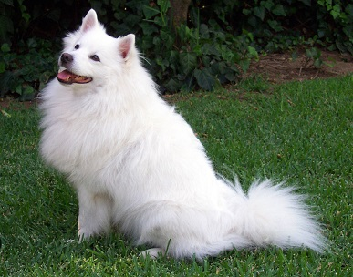

**output: scores**

The output is a set of scores over the [classes](https://raw.githubusercontent.com/pytorch/hub/master/imagenet_classes.txt) in Imagenet. The sum of all the scores over all the classes is equal to 1. The top 5 are displayed:

```
Samoyed 0.8846219182014465
Arctic fox 0.04580527916550636
white wolf 0.04427633807063103
Pomeranian 0.005621336866170168
Great Pyrenees 0.004651939496397972
```

- [Conv2d](https://pytorch.org/docs/stable/generated/torch.nn.Conv2d.html): Convolution
- [BatchNorm2d](https://pytorch.org/docs/stable/generated/torch.nn.BatchNorm2d.html): Batch Normalisation
- [ReLU](https://pytorch.org/docs/stable/generated/torch.nn.ReLU.html): rectified linear unit function (activation function)
- [MaxPool2d](https://pytorch.org/docs/stable/generated/torch.nn.MaxPool2d.html): Max Pooling
- [Linear](https://pytorch.org/docs/stable/generated/torch.nn.Linear.html) : linear transformation

```
ResNet(
  (conv1): Conv2d(3, 64, kernel_size=(7, 7), stride=(2, 2), padding=(3, 3), bias=False)
  (bn1): BatchNorm2d(64, eps=1e-05, momentum=0.1, affine=True, track_running_stats=True)
  (relu): ReLU(inplace=True)
  (maxpool): MaxPool2d(kernel_size=3, stride=2, padding=1, dilation=1, ceil_mode=False)
  (layer1): Sequential(
    (0): BasicBlock(
      (conv1): Conv2d(64, 64, kernel_size=(3, 3), stride=(1, 1), padding=(1, 1), bias=False)
      (bn1): BatchNorm2d(64, eps=1e-05, momentum=0.1, affine=True, track_running_stats=True)
      (relu): ReLU(inplace=True)
      (conv2): Conv2d(64, 64, kernel_size=(3, 3), stride=(1, 1), padding=(1, 1), bias=False)
      (bn2): BatchNorm2d(64, eps=1e-05, momentum=0.1, affine=True, track_running_stats=True)
    )
    (1): BasicBlock(
      (conv1): Conv2d(64, 64, kernel_size=(3, 3), stride=(1, 1), padding=(1, 1), bias=False)
      (bn1): BatchNorm2d(64, eps=1e-05, momentum=0.1, affine=True, track_running_stats=True)
      (relu): ReLU(inplace=True)
      (conv2): Conv2d(64, 64, kernel_size=(3, 3), stride=(1, 1), padding=(1, 1), bias=False)
      (bn2): BatchNorm2d(64, eps=1e-05, momentum=0.1, affine=True, track_running_stats=True)
    )
  )
  (layer2): Sequential(
    (0): BasicBlock(
      (conv1): Conv2d(64, 128, kernel_size=(3, 3), stride=(2, 2), padding=(1, 1), bias=False)
      (bn1): BatchNorm2d(128, eps=1e-05, momentum=0.1, affine=True, track_running_stats=True)
      (relu): ReLU(inplace=True)
      (conv2): Conv2d(128, 128, kernel_size=(3, 3), stride=(1, 1), padding=(1, 1), bias=False)
      (bn2): BatchNorm2d(128, eps=1e-05, momentum=0.1, affine=True, track_running_stats=True)
      (downsample): Sequential(
        (0): Conv2d(64, 128, kernel_size=(1, 1), stride=(2, 2), bias=False)
        (1): BatchNorm2d(128, eps=1e-05, momentum=0.1, affine=True, track_running_stats=True)
      )
    )
    (1): BasicBlock(
      (conv1): Conv2d(128, 128, kernel_size=(3, 3), stride=(1, 1), padding=(1, 1), bias=False)
      (bn1): BatchNorm2d(128, eps=1e-05, momentum=0.1, affine=True, track_running_stats=True)
      (relu): ReLU(inplace=True)
      (conv2): Conv2d(128, 128, kernel_size=(3, 3), stride=(1, 1), padding=(1, 1), bias=False)
      (bn2): BatchNorm2d(128, eps=1e-05, momentum=0.1, affine=True, track_running_stats=True)
    )
```

[output cut: 29 more lines]

```
        (0): Conv2d(256, 512, kernel_size=(1, 1), stride=(2, 2), bias=False)
        (1): BatchNorm2d(512, eps=1e-05, momentum=0.1, affine=True, track_running_stats=True)
      )
    )
    (1): BasicBlock(
      (conv1): Conv2d(512, 512, kernel_size=(3, 3), stride=(1, 1), padding=(1, 1), bias=False)
      (bn1): BatchNorm2d(512, eps=1e-05, momentum=0.1, affine=True, track_running_stats=True)
      (relu): ReLU(inplace=True)
      (conv2): Conv2d(512, 512, kernel_size=(3, 3), stride=(1, 1), padding=(1, 1), bias=False)
      (bn2): BatchNorm2d(512, eps=1e-05, momentum=0.1, affine=True, track_running_stats=True)
    )
  )
  (avgpool): AdaptiveAvgPool2d(output_size=(1, 1))
  (fc): Linear(in_features=512, out_features=1000, bias=True)
)
```

## 3.3 VGG

https://pytorch.org/hub/pytorch_vision_vgg/

```
VGG(
  (features): Sequential(
    (0): Conv2d(3, 64, kernel_size=(3, 3), stride=(1, 1), padding=(1, 1))
    (1): ReLU(inplace=True)
    (2): MaxPool2d(kernel_size=2, stride=2, padding=0, dilation=1, ceil_mode=False)
    (3): Conv2d(64, 128, kernel_size=(3, 3), stride=(1, 1), padding=(1, 1))
    (4): ReLU(inplace=True)
    (5): MaxPool2d(kernel_size=2, stride=2, padding=0, dilation=1, ceil_mode=False)
    (6): Conv2d(128, 256, kernel_size=(3, 3), stride=(1, 1), padding=(1, 1))
    (7): ReLU(inplace=True)
    (8): Conv2d(256, 256, kernel_size=(3, 3), stride=(1, 1), padding=(1, 1))
    (9): ReLU(inplace=True)
    (10): MaxPool2d(kernel_size=2, stride=2, padding=0, dilation=1, ceil_mode=False)
    (11): Conv2d(256, 512, kernel_size=(3, 3), stride=(1, 1), padding=(1, 1))
    (12): ReLU(inplace=True)
    (13): Conv2d(512, 512, kernel_size=(3, 3), stride=(1, 1), padding=(1, 1))
    (14): ReLU(inplace=True)
    (15): MaxPool2d(kernel_size=2, stride=2, padding=0, dilation=1, ceil_mode=False)
    (16): Conv2d(512, 512, kernel_size=(3, 3), stride=(1, 1), padding=(1, 1))
    (17): ReLU(inplace=True)
    (18): Conv2d(512, 512, kernel_size=(3, 3), stride=(1, 1), padding=(1, 1))
    (19): ReLU(inplace=True)
    (20): MaxPool2d(kernel_size=2, stride=2, padding=0, dilation=1, ceil_mode=False)
  )
  (avgpool): AdaptiveAvgPool2d(output_size=(7, 7))
  (classifier): Sequential(
    (0): Linear(in_features=25088, out_features=4096, bias=True)
    (1): ReLU(inplace=True)
    (2): Dropout(p=0.5, inplace=False)
    (3): Linear(in_features=4096, out_features=4096, bias=True)
    (4): ReLU(inplace=True)
    (5): Dropout(p=0.5, inplace=False)
    (6): Linear(in_features=4096, out_features=1000, bias=True)
  )
)
```

## 3.4 UNet

https://pytorch.org/hub/mateuszbuda_brain-segmentation-pytorch_unet/

# 4 Matlab

- [example on how to use a pretrained Convolutional Neural Network (CNN) as a feature extractor for training an image category classifier](https://uk.mathworks.com/help/vision/ug/image-category-classification-using-deep-learning.html)